# Assignment6_TS

Weijie Gao

11/9/2017

```r
dataPath <- "~/Google Drive/2017 Fall/Time Series/Week6"
data <- read.csv(paste(dataPath,"Gas Furnace Dataset.csv",sep='/'),header=TRUE)
```

```r
head(data)
```

```
##   Input.gas.rate Outlet.gas.CO2.percentage
## 1         -0.109                      53.8
## 2          0.000                      53.6
## 3          0.178                      53.5
## 4          0.339                      53.5
## 5          0.373                      53.4
## 6          0.441                      53.1
```

```r
library("TSA")
```

```
## locfit 1.5-9.1    2013-03-22
```

```r
library(forecast)
library(tseries)
library(fracdiff)
```

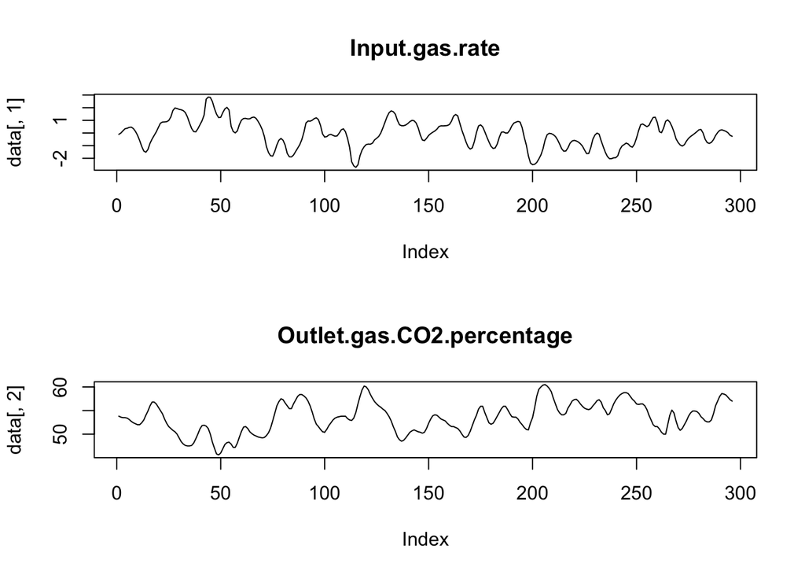

```r
par(mfrow=c(2,1))
plot(data[,1], type = "l", main = "Input.gas.rate")
plot(data[,2], type = "l", main = "Outlet.gas.CO2.percentage")
```

```r
fit1 <- lm(Outlet.gas.CO2.percentage~Input.gas.rate, data = data)
summary(fit1)
```

```
##
## Call:
## lm(formula = Outlet.gas.CO2.percentage ~ Input.gas.rate, data = data)
##
## Residuals:
##     Min      1Q  Median      3Q     Max
## -6.2139 -2.0642  0.0954  2.2743  6.5750
##
## Coefficients:
##                Estimate Std. Error t value Pr(>|t|)
## (Intercept)     53.4269     0.1633 327.116   <2e-16 ***
## Input.gas.rate  -1.4460     0.1523  -9.495   <2e-16 ***
## ---
## Signif. codes:  0 '***' 0.001 '**' 0.01 '*' 0.05 '.' 0.1 ' ' 1
##
## Residual standard error: 2.806 on 294 degrees of freedom
## Multiple R-squared:  0.2347, Adjusted R-squared:  0.2321
## F-statistic: 90.16 on 1 and 294 DF,  p-value: < 2.2e-16
```

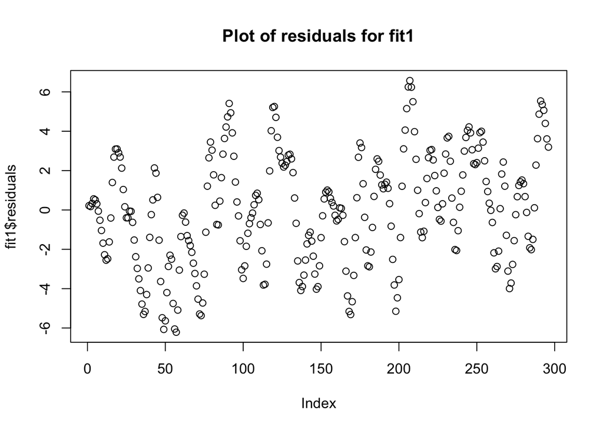

```r
plot(fit1$residuals,main="Plot of residuals for fit1")
```

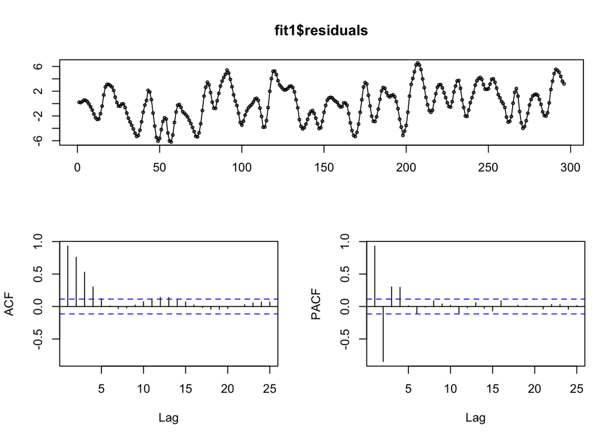

```r
tsdisplay(fit1$residuals)
```

According to the plot of Input.gas.rate and Outlet.gas.CO2.percentage, both data shows seasonality. From the ACF plot of residuals, we could see there is some seasonality in the residuals of the model. There is autocorrelation in residuals. In ACF plot, some spikes are significant until lag 5, and around lag 10-15, spikes become significant again. In PACF plot, there are few significant spikes as well. The linear model is not a good model in terms of residuals behavior and r-squared (only 0.23).

```r
# self-defined function to facilitate the following analysis
fun_arma <- function(x, arma.model) {
p <- arma.model$arma[1]
q <- arma.model$arma[2]
num.coef <- p + q
ar.coef <- arma.model$coef[seq_len(p)]
ma.coef <- arma.model$coef[p + seq_len(q)]
if (q == 0) {
infinite.ar.coef <- ar.coef
} else {
infinite.ar.coef <- -ARMAtoMA(-ma.coef, -ar.coef, num.coef)
}
return(as.vector(filter(x, c(1, -infinite.ar.coef), side=1)))
}
```

```r
Outlet.gas.CO2.percentage <- data$Outlet.gas.CO2.percentage
Input.gas.rate <- data$Input.gas.rate
fit2 <- arima(fit1$residuals, order = c(0,0,1), include.mean = FALSE)
adj.fit2.co2 <- fun_arma(Outlet.gas.CO2.percentage, fit2)
adj.fit2.gas <- fun_arma(Input.gas.rate, fit2)
fit2.adj <- lm(adj.fit2.co2~adj.fit2.gas)
summary(fit2.adj)
```

```
##
## Call:
## lm(formula = adj.fit2.co2 ~ adj.fit2.gas)
##
## Residuals:
##      Min       1Q   Median       3Q      Max
## -1.80550 -0.53656 -0.08934  0.49619  2.50859
##
## Coefficients:
##              Estimate Std. Error t value Pr(>|t|)
## (Intercept)   3.11191    0.04193  74.211  < 2e-16 ***
## adj.fit2.gas  0.66463    0.12832   5.179 4.15e-07 ***
## ---
## Signif. codes:  0 '***' 0.001 '**' 0.01 '*' 0.05 '.' 0.1 ' ' 1
##
## Residual standard error: 0.7202 on 293 degrees of freedom
##   (1 observation deleted due to missingness)
## Multiple R-squared:  0.08388,    Adjusted R-squared:  0.08075
## F-statistic: 26.83 on 1 and 293 DF,  p-value: 4.146e-07
```

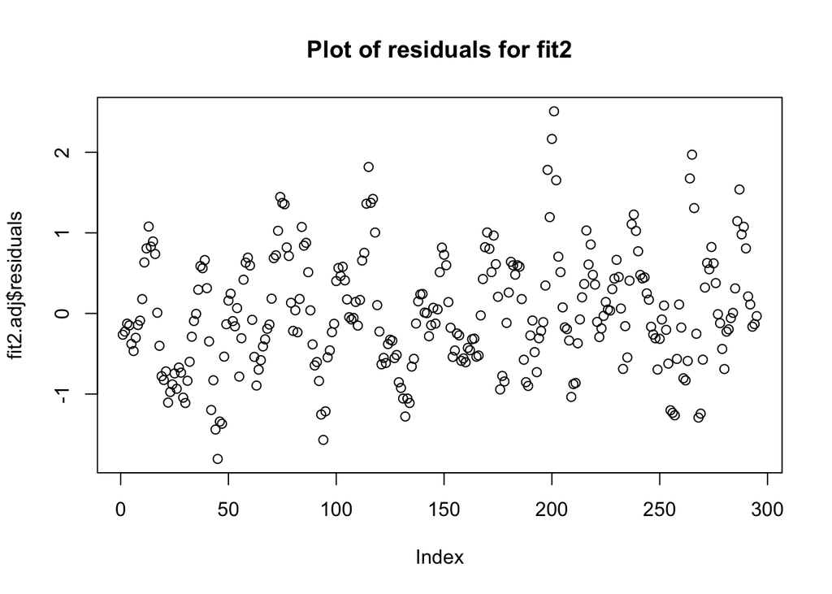

```r
plot(fit2.adj$residuals,main="Plot of residuals for fit2")
```

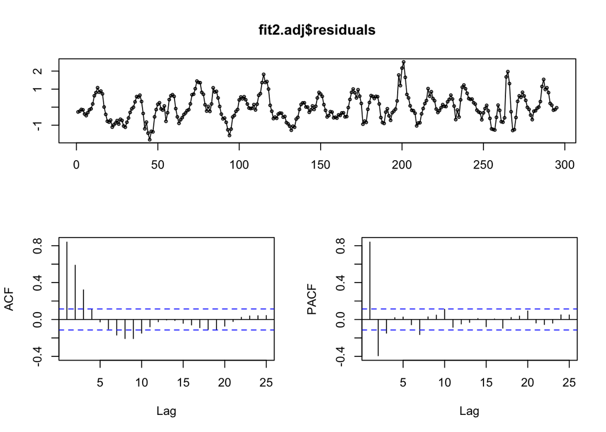

```r
tsdisplay(fit2.adj$residuals)
```

As we can see, the model does not show any significant improvement compared to the model in Task1. In time series plot of residuals, there still shows seasonal variations. In its ACF and PACF plot of residuals, there are few significant spikes suggesting residuals are autocorrelated. Now some spikes in ACF plot become negative. The model has R-squared of 0.08, which is actually worse than the previous model.

```r
fit3 <- arima(fit1$residuals, order = c(1,0,0), include.mean = FALSE)
adj.fit3.co2 <- fun_arma(Outlet.gas.CO2.percentage, fit3)
adj.fit3.gas <- fun_arma(Input.gas.rate, fit3)
fit3.adj <- lm(adj.fit3.co2~adj.fit3.gas)
summary(fit3.adj)
```

```
##
## Call:
## lm(formula = adj.fit3.co2 ~ adj.fit3.gas)
##
## Residuals:
##     Min      1Q  Median      3Q     Max
## -1.8542 -0.5284 -0.1004  0.5203  2.5393
##
## Coefficients:
##              Estimate Std. Error t value Pr(>|t|)
## (Intercept)   3.56037    0.04232  84.125  < 2e-16 ***
## adj.fit3.gas  0.64016    0.12934   4.949 1.26e-06 ***
## ---
## Signif. codes:  0 '***' 0.001 '**' 0.01 '*' 0.05 '.' 0.1 ' ' 1
##
## Residual standard error: 0.7269 on 293 degrees of freedom
##   (1 observation deleted due to missingness)
## Multiple R-squared:  0.07716,    Adjusted R-squared:  0.07401
## F-statistic:  24.5 on 1 and 293 DF,  p-value: 1.257e-06
```

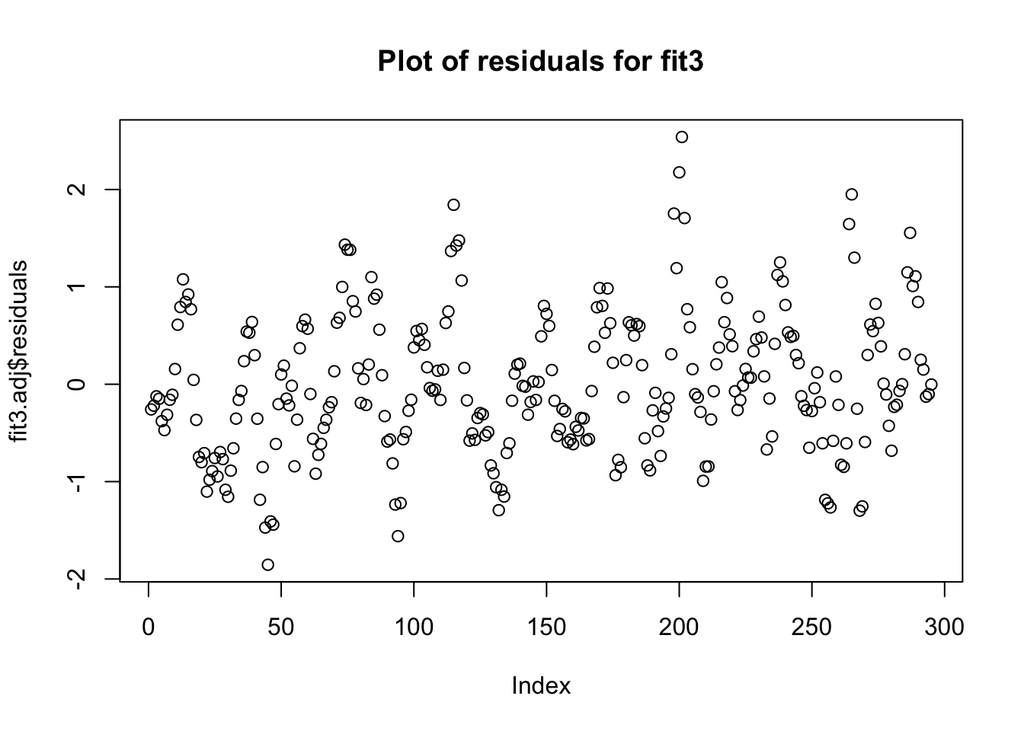

```r
plot(fit3.adj$residuals,main="Plot of residuals for fit3")
```

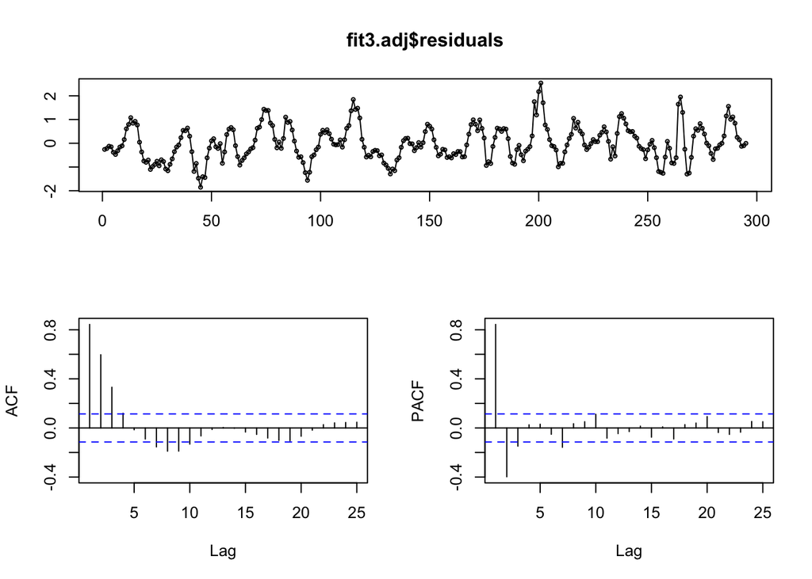

```r
tsdisplay(fit3.adj$residuals)
```

This model still does not show any significant improvement compared to the model in Task1.

```r
fit4 <- arima(fit1$residuals, order = c(0,0,2), include.mean = FALSE)
adj.fit4.co2 <- fun_arma(Outlet.gas.CO2.percentage, fit4)
adj.fit4.gas <- fun_arma(Input.gas.rate, fit4)
fit4.adj <- lm(adj.fit4.co2~adj.fit4.gas)
summary(fit4.adj)
```

```
##
## Call:
## lm(formula = adj.fit4.co2 ~ adj.fit4.gas)
##
## Residuals:
##     Min      1Q  Median      3Q     Max
## -5.4559 -1.8813  0.0056  2.0832  6.3576
##
## Coefficients:
##              Estimate Std. Error t value Pr(>|t|)
## (Intercept)   56.3401     0.1525  369.48   <2e-16 ***
## adj.fit4.gas  -1.7920     0.1441  -12.44   <2e-16 ***
## ---
## Signif. codes:  0 '***' 0.001 '**' 0.01 '*' 0.05 '.' 0.1 ' ' 1
##
## Residual standard error: 2.61 on 292 degrees of freedom
##   (2 observations deleted due to missingness)
## Multiple R-squared:  0.3463, Adjusted R-squared:  0.344
## F-statistic: 154.7 on 1 and 292 DF,  p-value: < 2.2e-16
```

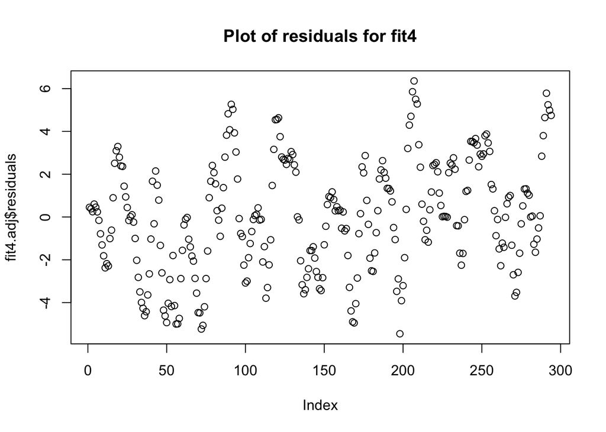

```r
plot(fit4.adj$residuals,main="Plot of residuals for fit4")
```

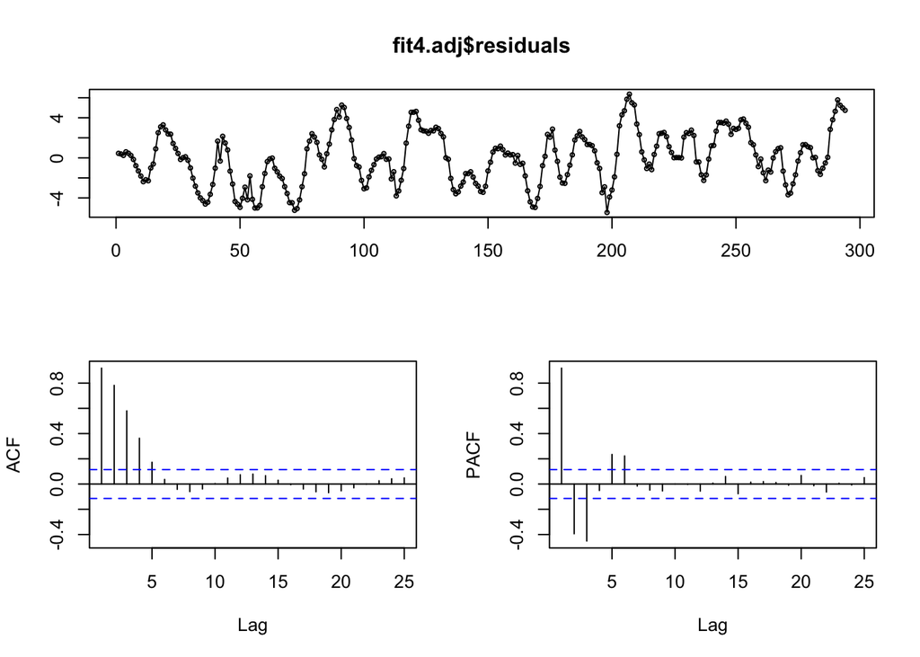

```r
tsdisplay(fit4.adj$residuals)
```

Residuals in this model still show autocorrelation and seasonality looking at its plot and ACF, PACF plot. But significant spikes are fewer in larger lags, which performs better than previous models.

```r
fit5 <- arima(fit1$residuals, order = c(2,0,0), include.mean = FALSE)
adj.fit5.co2 <- fun_arma(Outlet.gas.CO2.percentage, fit5)
adj.fit5.gas <- fun_arma(Input.gas.rate, fit5)
fit5.adj <- lm(adj.fit5.co2~adj.fit5.gas)
summary(fit5.adj)
```

```
##
## Call:
## lm(formula = adj.fit5.co2 ~ adj.fit5.gas)
##
## Residuals:
##      Min       1Q   Median       3Q      Max
## -1.45122 -0.26222  0.00073  0.27453  1.48116
##
## Coefficients:
##              Estimate Std. Error t value Pr(>|t|)
## (Intercept)   6.55882    0.02587  253.56  < 2e-16 ***
## adj.fit5.gas -0.37498    0.12583   -2.98  0.00313 **
## ---
## Signif. codes:  0 '***' 0.001 '**' 0.01 '*' 0.05 '.' 0.1 ' ' 1
##
## Residual standard error: 0.4432 on 292 degrees of freedom
##   (2 observations deleted due to missingness)
## Multiple R-squared:  0.02951,    Adjusted R-squared:  0.02619
## F-statistic:  8.88 on 1 and 292 DF,  p-value: 0.003125
```

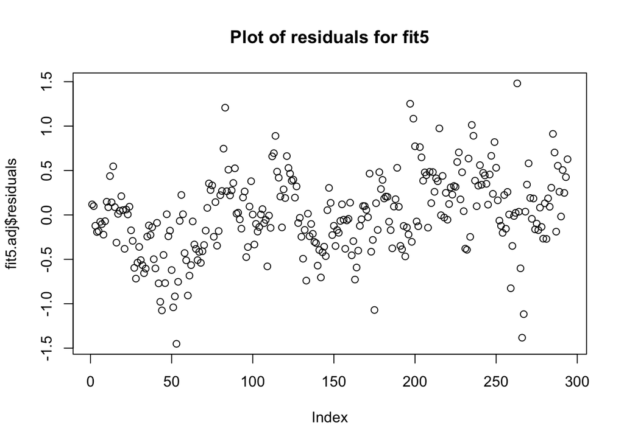

```r
plot(fit5.adj$residuals,main="Plot of residuals for fit5")
```

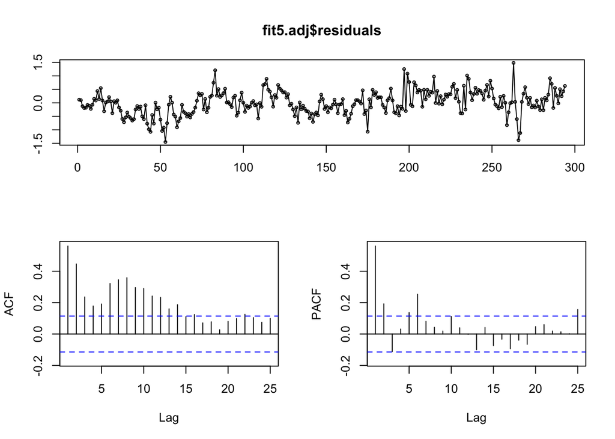

```r
tsdisplay(fit5.adj$residuals)
```

This model is the wrost so far because of its low R-squared of 0.03 and many significant spikes in its ACF plot of residuals. Residuals are autocorrelated and have seasonality.

```r
fit6 <- arima(fit1$residuals, order = c(2,0,2), include.mean = FALSE)
adj.fit6.co2 <- fun_arma(Outlet.gas.CO2.percentage, fit6)
adj.fit6.gas <- fun_arma(Input.gas.rate, fit6)
fit6.adj <- lm(adj.fit6.co2~adj.fit6.gas)
summary(fit6.adj)
```

```
##
## Call:
## lm(formula = adj.fit6.co2 ~ adj.fit6.gas)
##
## Residuals:
##      Min       1Q   Median       3Q      Max
## -1.53341 -0.39045 -0.02012  0.37813  1.70394
##
## Coefficients:
##              Estimate Std. Error  t value Pr(>|t|)
## (Intercept)   -5.1177     0.0319 -160.429  < 2e-16 ***
## adj.fit6.gas  -0.3549     0.1293   -2.745  0.00642 **
## ---
## Signif. codes:  0 '***' 0.001 '**' 0.01 '*' 0.05 '.' 0.1 ' ' 1
##
## Residual standard error: 0.545 on 290 degrees of freedom
##   (4 observations deleted due to missingness)
## Multiple R-squared:  0.02533,    Adjusted R-squared:  0.02197
## F-statistic: 7.536 on 1 and 290 DF,  p-value: 0.006425
```

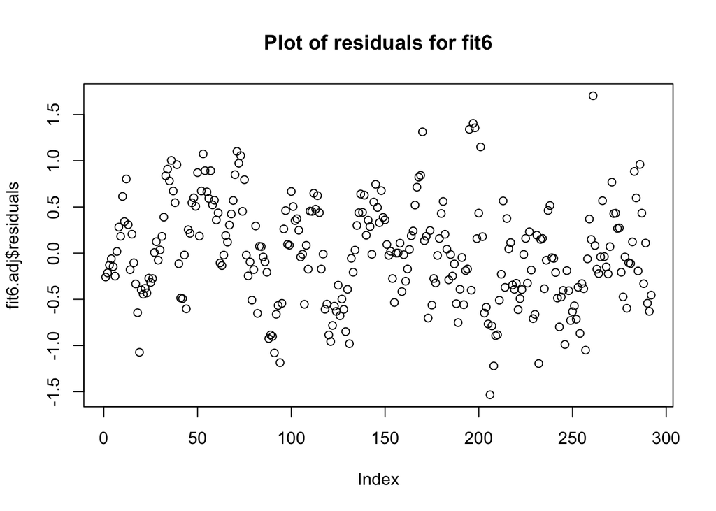

```r
plot(fit6.adj$residuals,main="Plot of residuals for fit6")
```

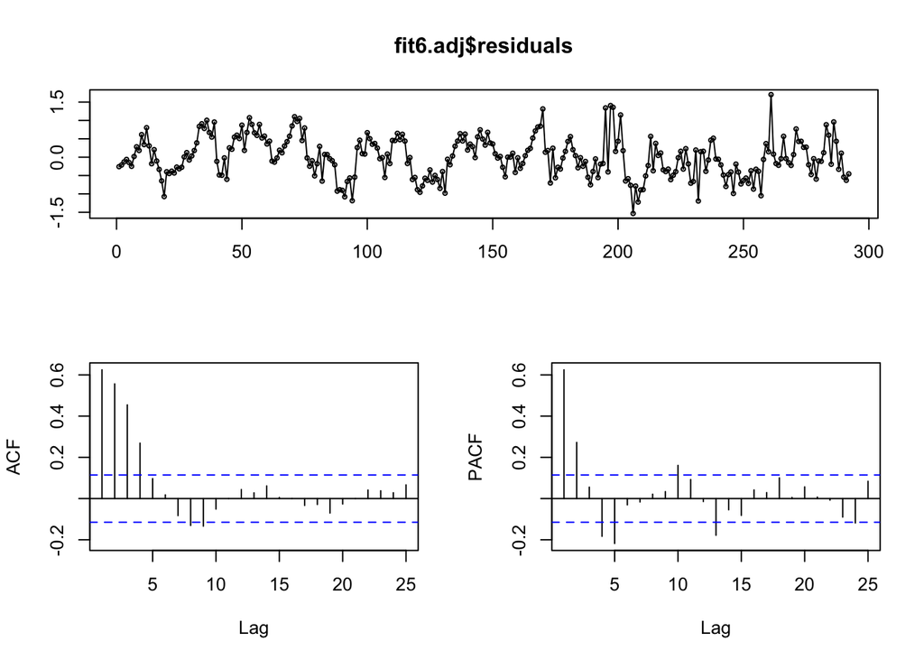

```r
tsdisplay(fit6.adj$residuals)
```

This model does not show any significant improvement compared to the model in Task1. Residuals in this model still show autocorrelation and seasonality looking at its plot and ACF, PACF plot. But significant spikes are fewer in larger lags, which performs better than model in Task 1.

```r
fit7 <- arfima(Outlet.gas.CO2.percentage, drange = c(0,0.5))
summary(fit7)
```

```
##
## Call:
##   arfima(y = Outlet.gas.CO2.percentage, drange = c(0, 0.5))
##
## *** Warning during (fdcov) fit: unable to compute correlation matrix; maybe change 'h'
##
## Coefficients:
##        Estimate
## d         0.404
## ar.ar1    0.268
## ar.ar2    0.568
## ar.ar3    0.452
## ar.ar4   -0.699
## ma.ma1   -1.430
## ma.ma2   -1.000
## sigma[eps] = 0.3283512
## [d.tol = 0.0001221, M = 100, h = 9.708e-07]
## Log likelihood: -91.13 ==> AIC = 198.2652 [8 deg.freedom]
```

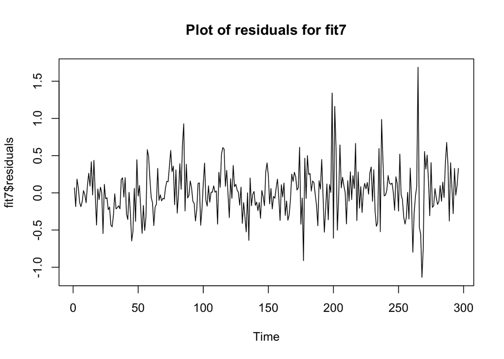

```r
plot(fit7$residuals,main="Plot of residuals for fit7")
```

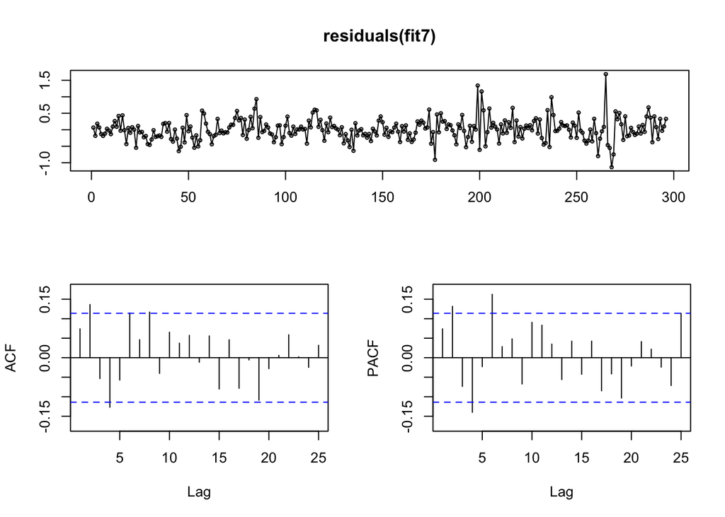

```r
tsdisplay(residuals(fit7))
```